# ARIMA Time Series Forecasting

[Sushank Pokhrel (Homepage)](https://sushank.com.np)

#### Fetching necessary libraries

```r
library(forecast)
library(tseries)
```

### 1. Loading the sales data

```r
sales <- read.csv(
  "D:/Drive/r_training/Datasets/time series data/sales.csv"
)
```

### 2. Understanding the structure of the data

```r
str(sales)
```

```
## 'data.frame':    156 obs. of  2 variables:
##  $ Month  : chr  "01-Jan-72" "01-Feb-72" "01-Mar-72" "01-Apr-72" ...
##  $ Sales_k: int  580 610 630 670 710 710 630 590 580 570 ...
```

The `str()` function in R shows the internal structure of the sales data frame. This will tell you the number of observations, the variables (columns) in the dataset, and the data types of these variables.

For instance, you might see that sales$Sales_k is a numeric vector, and it likely represents the sales data in thousands or another unit.

### 3. Viewing the first few rows of the dataset

```r
sales |> head(n = 12)
```

```
##        Month Sales_k
## 1  01-Jan-72     580
## 2  01-Feb-72     610
## 3  01-Mar-72     630
## 4  01-Apr-72     670
## 5  01-May-72     710
## 6  01-Jun-72     710
## 7  01-Jul-72     630
## 8  01-Aug-72     590
## 9  01-Sep-72     580
## 10 01-Oct-72     570
## 11 01-Nov-72     560
## 12 01-Dec-72     570
```

The `head()` function shows the first 12 rows of the dataset. This gives you a quick snapshot of the data’s structure, including the first few months or observations in the time series.

It’s crucial to look at the first few entries to understand the time span and periodicity of the data. This helps in setting up the time series object later on.

### 4. Converting sales data into a time series object

```r
sales_ts <- ts(sales$Sales_k,
               start = 1972,
               frequency = 12
)
```

The `ts()` function is used to convert the sales data (sales$Sales_k) into a time series object.

- `start = 1972`: Specifies that the time series starts in 1972. This is the year of the first data point.
- `frequency = 12`: Indicates that the data is monthly, with 12 periods per year. This is important because ARIMA requires the time series to be evenly spaced in time.

Time series data requires the data to be in a format that recognizes the temporal order. By using the ts() function, R recognizes the sequential nature of the data, which is essential for time series analysis and modeling.

### 5. Plotting the time series data

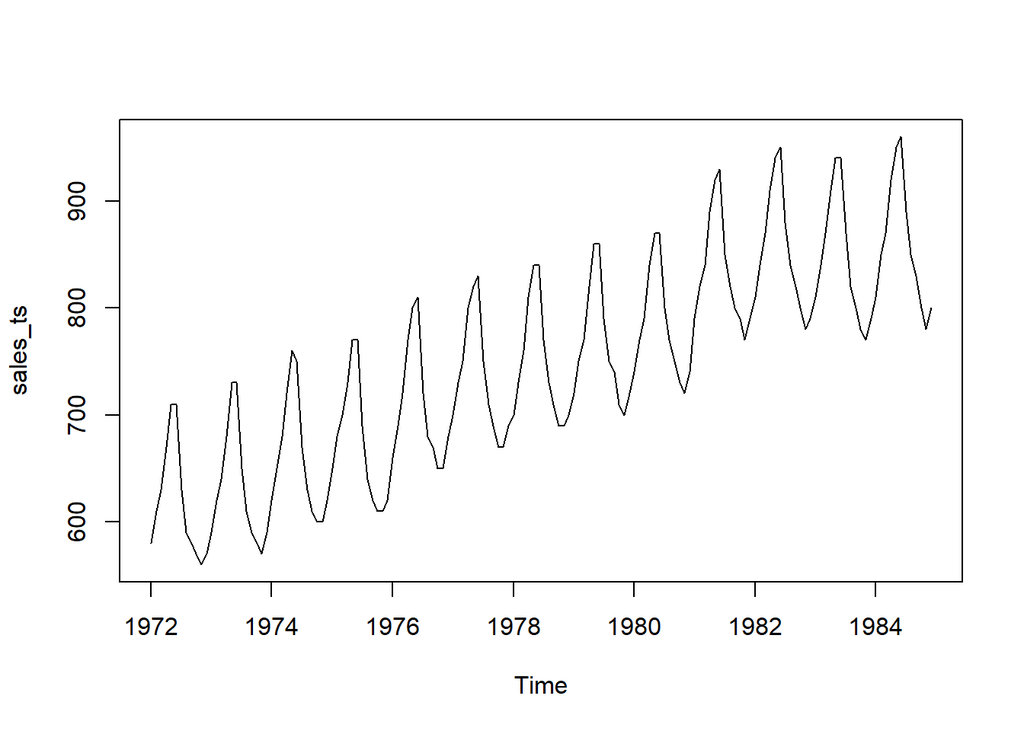

```r
plot(sales_ts)
```

The `plot()` function generates a simple line plot of the time series. This visualization is helpful to understand the trend, seasonality, and overall pattern of the data.

#### Autocorrelation and Partial Autocorrelation Functions (ACF & PACF)

#### Autocorrelation Function (ACF)

To check for stationarity, we can examine the autocorrelation function (ACF) and partial autocorrelation function (PACF). These functions help us identify the relationships between the data points over time.

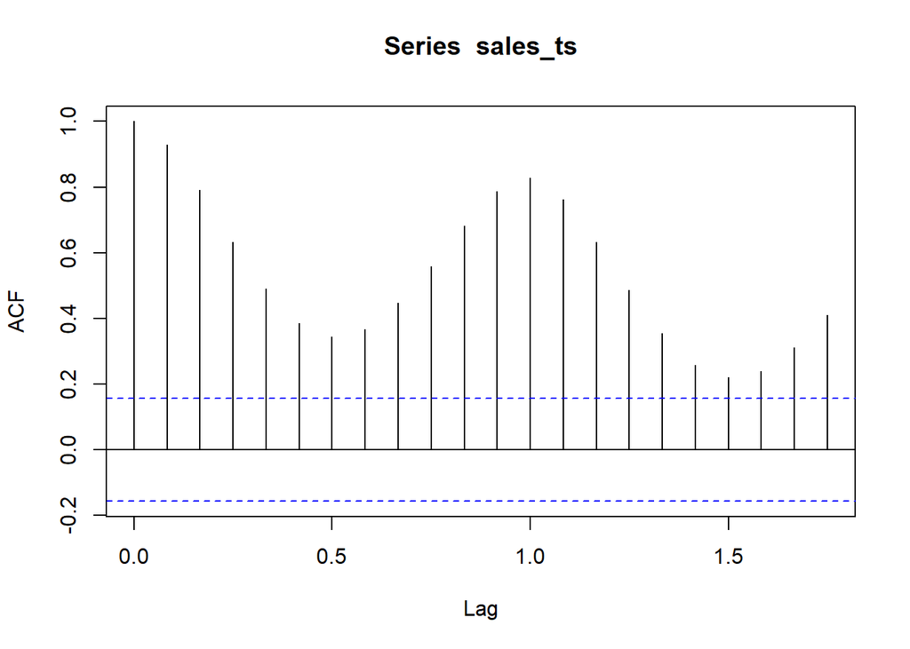

```r
acf(sales_ts)
```

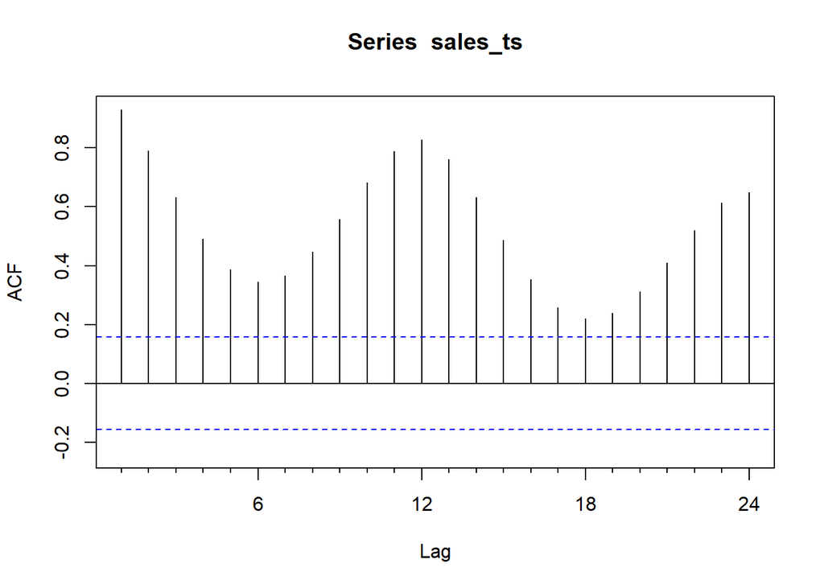

```r
Acf(sales_ts)
```

These function calculates the autocorrelation of the time series. Autocorrelation measures the correlation between the values of the time series at different lags.

If the time series is non-stationary, the autocorrelation will typically show slow decay or significant correlations at high lags. A stationary series, on the other hand, will have an ACF that drops off quickly, showing no significant correlation beyond the first few lags.

- `acf()` from stats: This function provides a fractional lag scale, which is more common in time series analysis where you’re dealing with continuous-time data or high-frequency data (like daily or minute-level time series). It might be particularly useful when working with irregularly spaced data or when modeling continuous phenomena that aren’t restricted to integer time steps. This function gives the value of lag 0, which always has perfectly 1 correlation.
- `Acf()` from forecast: The `Acf()` function, being part of the forecast package, is typically used in forecasting applications where time series data is often discrete (e.g., monthly, quarterly, yearly). In this context, it is more natural to use integer lags to represent shifts in time periods because most forecasting models (like ARIMA) are designed to work with data that has a well-defined, consistent time interval (such as monthly or yearly). This doesn’t give the lag 0 value.

#### Partial Autocorrelation Function (PACF)

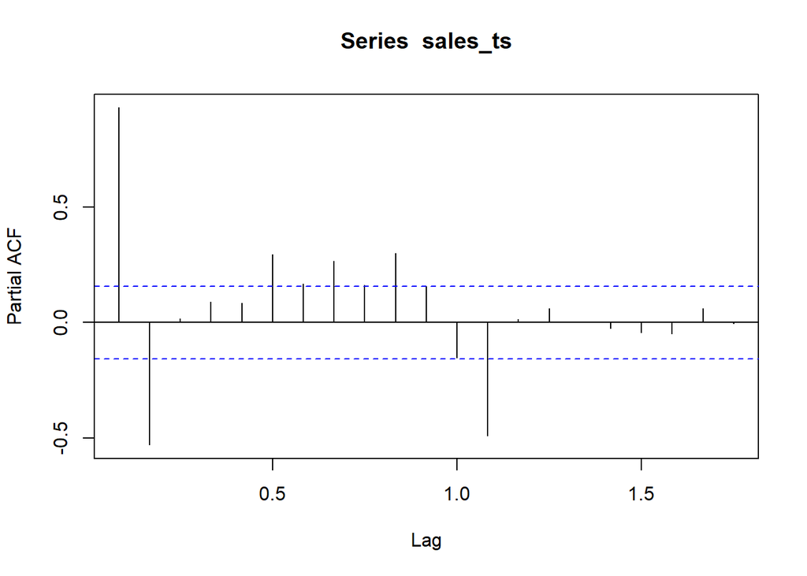

```r
pacf(sales_ts)
```

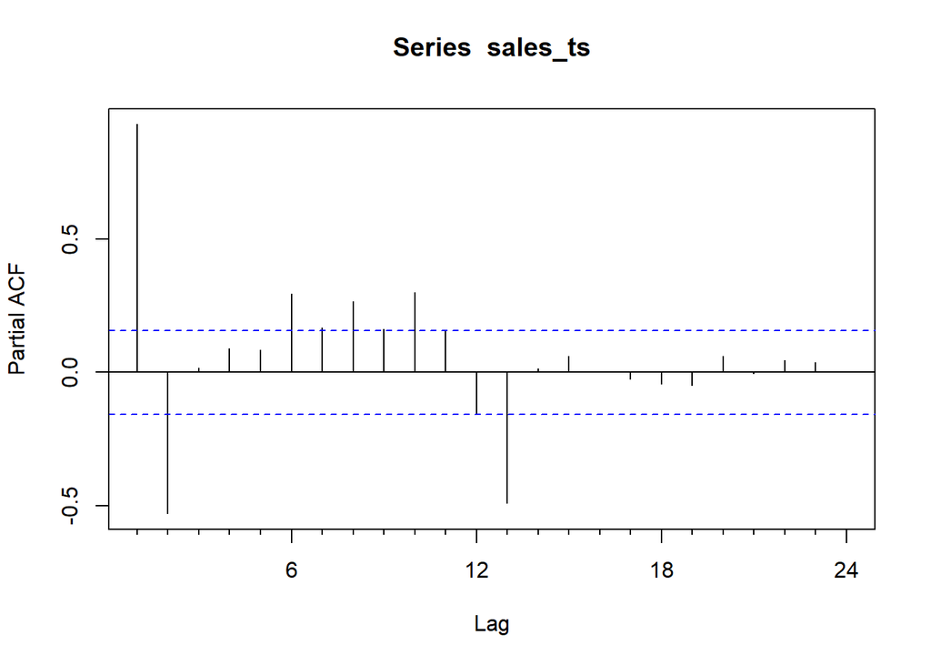

```r
Pacf(sales_ts)
```

It calculates the partial autocorrelation of the time series. It helps to identify the lag at which the autocorrelation becomes statistically significant, considering only the direct relationship between observations.

The PACF is useful for determining the appropriate number of lags to include in an AR (AutoRegressive) model, a component of ARIMA.

- The working theory and `pacf()` and `Pacf()` are quite similar to the `acf()` and `Acf()` respectively.

**ACF shows how well the present value of the series is related to its past values over various time lags. PACF measures the correlation between a series and its lags after removing the influence of shorter lags. For ARIMA modeling, the ACF and PACF help us decide on the orders of AR, I, and MA components of the model.**

#### Augmented Dickey-Fuller (ADF) Test

The Augmented Dickey-Fuller (ADF) test is a statistical test used to determine whether a time series is stationary or has a unit root (i.e., it is non-stationary). For ARIMA modeling, stationarity is a crucial requirement because the model assumes that the statistical properties (like the mean and variance) of the time series are constant over time.

```r
adf.test(sales_ts) # here we have not considered seasonal variation.
```

```
##
##  Augmented Dickey-Fuller Test
##
## data:  sales_ts
## Dickey-Fuller = -8.7644, Lag order = 5, p-value = 0.01
## alternative hypothesis: stationary
```

The ADF test is applied to the sales_ts time series object. The null hypothesis of the test is that the series is non-stationary (i.e., it has a unit root). If the p-value is low (typically < 0.05), we reject the null hypothesis and conclude that the series is stationary.

Results:

- Dickey-Fuller statistic = -8.7644
- p-value = 0.01. The p-value is less than 0.05, so the test suggests that the series is stationary. However, this might be misleading because the data has seasonal variation, which the test does not account for.

The ADF test adjusts for higher-order autocorrelations in the time series data by adding lagged differences of the time series as predictors. If the series is found to have a unit root, it suggests that the series has a trend, and may need differencing (or other transformations) to make it stationary.

But we have a very convenient way of doing arima modeling in R by using the function `auto.arima()` which determines all the required parameters for us. This is studied below.

### 7. Fitting the ARIMA Model

The `auto.arima()` function in the forecast package is used to automatically fit the best ARIMA model to the data. The function tries different combinations of AR (AutoRegressive), I (Integrated), and MA (Moving Average) parameters to minimize an information criterion, typically AIC (Akaike Information Criterion).

```r
sales_model <- auto.arima(
  sales_ts,
  ic = "aic",
  trace = T
)
```

```
##
##  Fitting models using approximations to speed things up...
##
##  ARIMA(2,0,2)(1,1,1)[12] with drift         : Inf
##  ARIMA(0,0,0)(0,1,0)[12] with drift         : 1129.131
##  ARIMA(1,0,0)(1,1,0)[12] with drift         : 922.5469
##  ARIMA(0,0,1)(0,1,1)[12] with drift         : 1000.224
##  ARIMA(0,0,0)(0,1,0)[12]                    : 1266.458
##  ARIMA(1,0,0)(0,1,0)[12] with drift         : 929.7761
##  ARIMA(1,0,0)(2,1,0)[12] with drift         : 921.6905
##  ARIMA(1,0,0)(2,1,1)[12] with drift         : 910.6733
##  ARIMA(1,0,0)(1,1,1)[12] with drift         : 906.6267
##  ARIMA(1,0,0)(0,1,1)[12] with drift         : 897.6491
##  ARIMA(1,0,0)(0,1,2)[12] with drift         : 894.2417
##  ARIMA(1,0,0)(1,1,2)[12] with drift         : 903.4198
##  ARIMA(0,0,0)(0,1,2)[12] with drift         : Inf
##  ARIMA(2,0,0)(0,1,2)[12] with drift         : 896.9857
##  ARIMA(1,0,1)(0,1,2)[12] with drift         : 895.9364
##  ARIMA(0,0,1)(0,1,2)[12] with drift         : Inf
##  ARIMA(2,0,1)(0,1,2)[12] with drift         : 898.6955
##  ARIMA(1,0,0)(0,1,2)[12]                    : Inf
##
##  Now re-fitting the best model(s) without approximations...
##
##  ARIMA(1,0,0)(0,1,2)[12] with drift         : 974.9648
##
##  Best model: ARIMA(1,0,0)(0,1,2)[12] with drift
```

- `ic = "aic"`: The AIC criterion is used to select the best model. A lower AIC value suggests a better fit of the model to the data.
- `trace = T`: This argument prints the models being evaluated, so we can see the combinations of p, d, q, seasonal parameters, and whether drift is included in the model.

The model fitting process will try various combinations of seasonal and non-seasonal parameters. Based on the AIC values, the best model is selected.

Output of Model Fitting:

`ARIMA(1,0,0)(0,1,2)[12] with drift`

The model ARIMA(1,0,0)(0,1,2)[12] with drift refers to a seasonal ARIMA model with drift. Let’s break it down:

ARIMA(1, 0, 0): This is the non-seasonal part of the model.

AR(1): The model includes a first-order autoregressive term (AR), which means the current value depends on the previous value. d = 0: There is no differencing applied to the series, i.e., the series is assumed to be already stationary at the level (or it doesn’t need differencing). MA(0): The model does not include any moving average terms in the non-seasonal part. (0, 1, 2)[12]: This part represents the seasonal aspect of the model.

Seasonal differencing: The d = 1 indicates one seasonal difference, meaning the series is differenced once at the seasonal lag (12 periods, likely months or a year for monthly data). Seasonal MA(2): The model includes two seasonal moving average terms (sma1 and sma2), which are the moving average terms applied after seasonal differencing. With drift: The model includes a drift term. This term accounts for a linear trend or constant drift in the time series, representing a shift in the mean of the series over time.

Model Coefficients: From the output:

AR(1) coefficient: 0.8805. This means the value of the series at time t is influenced by 88.05% of the value at time t-1 (lag 1). Seasonal MA(1) coefficient (sma1): -0.5755. This term represents the effect of the first lag of the seasonal error (difference of 12 periods). Seasonal MA(2) coefficient (sma2): -0.1953. This term represents the effect of the second lag of the seasonal error (difference of 24 periods). Drift term: 1.7306. This term suggests that there is a constant increase of 1.7306 per time period (likely per month or per season), representing a trend or shift in the series. Equation Representation: The general form of an ARIMA model with drift is:

yt=μ+ϕ1yt−1+θ1ϵt−12+θ2ϵt−24+δt+ϵt

Where,

- yt is the value of the series at time t.
- μ is the drift term (here, 1.7306).
- 𝜙1 is the AR(1) coefficient (here, 0.8805).
- θ1 and θ2 are the seasonal MA(1) and MA(2) coefficients (here, -0.5755 and -0.1953, respectively).
- ϵt is the error term (white noise).
- The seasonal error terms are the residuals from 12 and 24 periods ago, denoted ϵt−12 and ϵt−24
- δ is the drift coefficient (1.7306), representing the trend in the series.

The `auto.arima()` function uses a stepwise algorithm to search through possible combinations of parameters. It evaluates each candidate model by minimizing the AIC (or BIC or AICc) score, which balances model fit and complexity. This helps avoid overfitting by penalizing more complex models.

The ARIMA(p, d, q) model structure is:

- AR (p): The number of past observations (lags) included in the model.
- I (d): The number of differences required to make the series stationary.
- MA (q): The number of lagged forecast errors in the model.

##### Arima Summary

```r
summary(sales_model)
```

```
## Series: sales_ts
## ARIMA(1,0,0)(0,1,2)[12] with drift
##
## Coefficients:
##          ar1     sma1     sma2   drift
##       0.8805  -0.5755  -0.1953  1.7306
## s.e.  0.0417   0.0934   0.0874  0.1297
##
## sigma^2 = 45.51:  log likelihood = -482.48
## AIC=974.96   AICc=975.4   BIC=989.81
##
## Training set error measures:
##                     ME     RMSE      MAE       MPE      MAPE      MASE
## Training set 0.1285307 6.390803 4.798829 0.0116146 0.6393458 0.2243609
##                    ACF1
## Training set -0.0632192
```

```r
sales_model
```

```
## Series: sales_ts
## ARIMA(1,0,0)(0,1,2)[12] with drift
##
## Coefficients:
##          ar1     sma1     sma2   drift
##       0.8805  -0.5755  -0.1953  1.7306
## s.e.  0.0417   0.0934   0.0874  0.1297
##
## sigma^2 = 45.51:  log likelihood = -482.48
## AIC=974.96   AICc=975.4   BIC=989.81
```

### 8. Evaluating Model Residuals

Once we have fitted the ARIMA model, it’s essential to check the residuals (the difference between the observed and predicted values) to ensure that the model has captured the underlying patterns in the data. The residuals should resemble white noise, meaning they should be uncorrelated and have constant variance.

#### Plotting ACF and PACF of Residuals

The ACF and PACF of the residuals help identify any remaining autocorrelation. Ideally, the residuals should have no significant autocorrelation at any lag (i.e., the ACF plot should show no significant spikes).

**ACF**

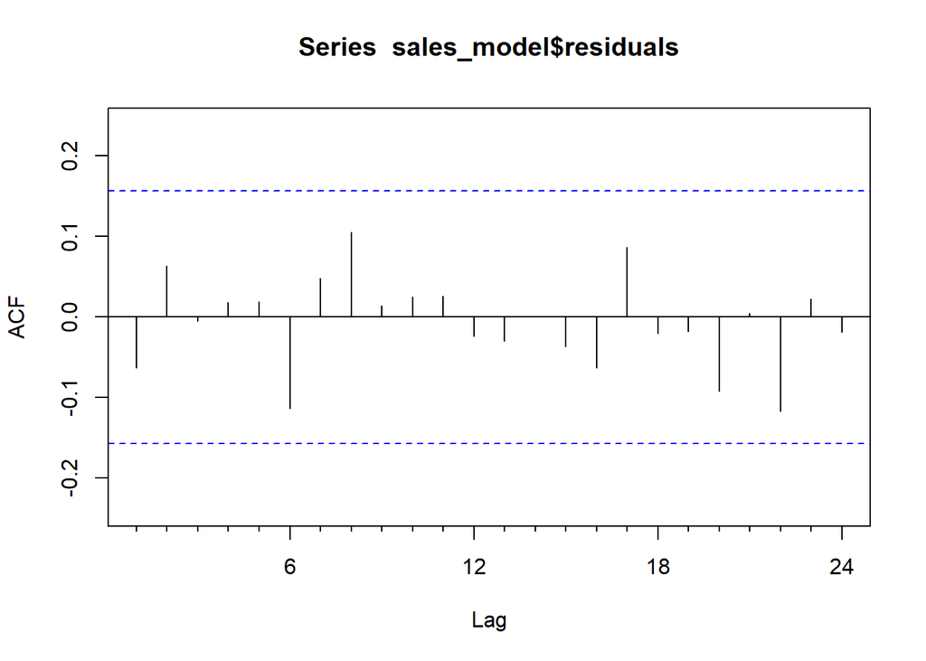

```r
Acf(sales_model$residuals)
```

If the residuals show significant autocorrelation or patterns, this indicates that the model is not capturing all the temporal dependencies in the data, and you might need to adjust the ARIMA model. The residuals should behave like white noise, meaning they should be normally distributed with a mean of 0 and no significant autocorrelations.

Here, the vertical lines are not crossing the horizontal blue-colored dots; therefore concluding that there is no autocorrelation between the residuals.

**PACF**

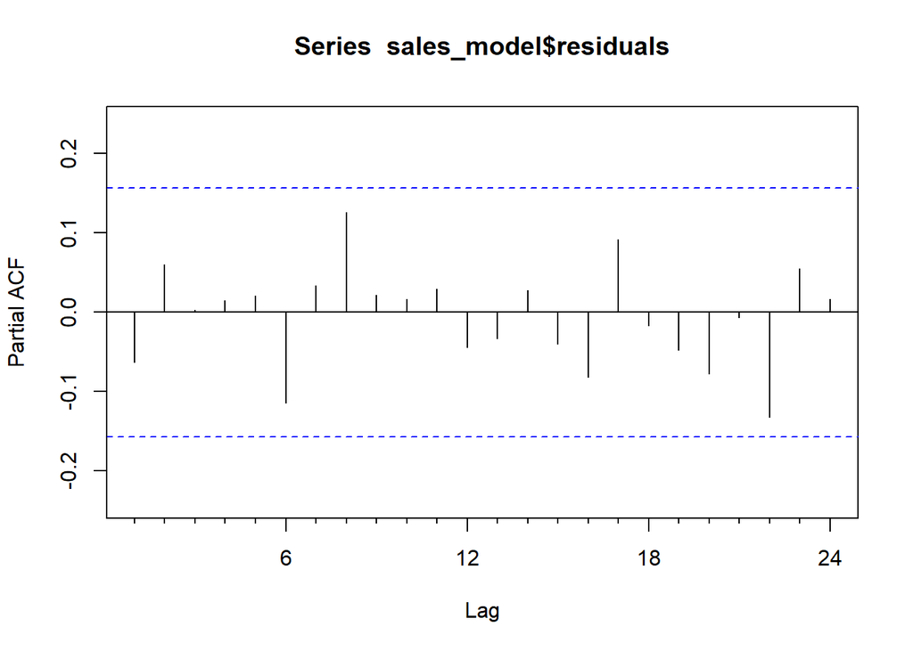

```r
Pacf(sales_model$residuals)
```

The PACF of residuals also helps assess whether there is any remaining structure in the data that the ARIMA model has not captured.

Here, the vertical lines are not crossing the horizontal blue-colored dots; therefore concluding that there is no autocorrelation between the residuals.

### 9. Forecasting Future Sales

Once the ARIMA model has been fitted, we can use it to predict future values. The forecast() function in R is used to generate forecasts from the fitted ARIMA model.

```r
sales_forecast <- forecast(
  sales_model,
  level = c(85, 95),
  h = 12 # Forecasting for the next 12 months.
)
```

- `level = c(85, 95)`: This argument specifies the confidence intervals for the forecast. Here, the forecast will include both an 85% and 95% confidence interval, meaning that we are 85% and 95% confident that the actual future values will fall within these intervals. These intervals represent the uncertainty around the forecast. A wider interval means more uncertainty, while a narrower interval implies higher confidence in the forecast.
- `h = 12`: This specifies the number of periods (months) for which we want to forecast. In this case, the forecast is extended 12 months into the future, starting from January 1985.

Point Forecast: This is the model’s prediction of the future value, based on the time series data and the underlying ARIMA model. Confidence Intervals:

Forecast Output

- Point Forecast: This is the predicted value for each month in the forecast period.
- Lo 85 and Hi 85: These are the lower and upper bounds of the 85% confidence interval for the forecast.
- Lo 95 and Hi 95: These are the lower and upper bounds of the 95% confidence interval for the forecast.

For example, for January 1985, the point forecast is 825.7956, and we are 85% confident that the actual value will lie between 816.0752 and 835.5161, and 95% confident it will lie between 812.5610 and 839.0303.

### 10. Plotting the Forecast

To visually inspect the forecast, we can plot the forecast values along with the historical data.

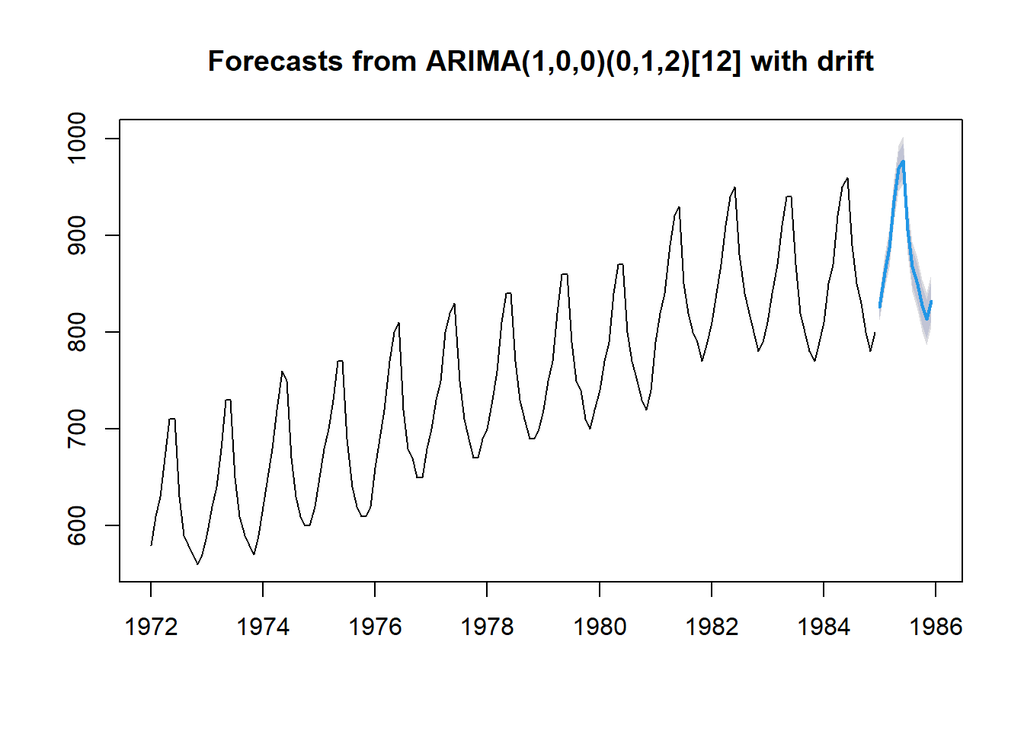

```r
plot(sales_forecast)
```

This will show:

- The original time series.
- The forecasted values for the next 12 months.
- The confidence intervals (shaded areas around the forecast).

### 11. Viewing the forecasted results.

```r
sales_forecast
```

```
##          Point Forecast    Lo 85    Hi 85    Lo 95     Hi 95
## Jan 1985       825.7956 816.0752 835.5161 812.5610  839.0303
## Feb 1985       862.4392 849.4901 875.3883 844.8086  880.0697
## Mar 1985       887.1877 872.2072 902.1682 866.7913  907.5841
## Apr 1985       936.1158 919.7331 952.4985 913.8102  958.4214
## May 1985       969.1290 951.7370 986.5210 945.4492  992.8087
## Jun 1985       977.1520 959.0163 995.2877 952.4597 1001.8443
## Jul 1985       905.6338 886.9420 924.3255 880.1844  931.0831
## Aug 1985       867.3802 848.2688 886.4916 841.3594  893.4009
## Sep 1985       849.4874 830.0572 868.9177 823.0326  875.9423
## Oct 1985       827.3194 807.6459 846.9930 800.5333  854.1056
## Nov 1985       813.6159 793.7561 833.4756 786.5763  840.6555
## Dec 1985       832.4911 812.4887 852.4934 805.2573  859.7248
```

This provides the data for Point Forecast, Lo and Hi values for the confidence interval.

### 12. Checking the Accuracy of the Forecast

After generating the forecast, it’s important to check the residuals (the differences between the observed and predicted values) to ensure the model is well-calibrated. This can be done using the Box-Ljung test, Box-Pierce test, and Ljung-Box test. If the p-value is low, it suggests the residuals are not independent, indicating a poor model fit.

#### Box-Ljung Test

The Box-Ljung test is used to test the null hypothesis that there is no autocorrelation in the residuals at different lags. If the p-value is greater than 0.05 (or another significance level we set), it suggests that the residuals do not exhibit significant autocorrelation, meaning the model has adequately captured the patterns in the data.

```r
Box.test(
  sales_forecast$residuals,
  lag = 10,
  type = "Ljung-Box"
)
```

```
##
##  Box-Ljung test
##
## data:  sales_forecast$residuals
## X-squared = 5.8871, df = 10, p-value = 0.8247
```

p-value = 0.8247: The p-value is greater than 0.05, indicating no significant autocorrelation in the residuals, suggesting that the model’s fit is good.

#### Box-Pierce Test

The Box-Pierce test is another test for autocorrelation in the residuals. It is similar to the Ljung-Box test but with a slightly different formulation. Again, we want the p-value to be greater than 0.05.

```r
Box.test(
  sales_forecast$residuals,
  type = "Box-Pierce"
)
```

```
##
##  Box-Pierce test
##
## data:  sales_forecast$residuals
## X-squared = 0.62348, df = 1, p-value = 0.4298
```

- p-value = 0.4298: The p-value is also greater than 0.05, indicating no significant autocorrelation.

#### Checking the residual values.

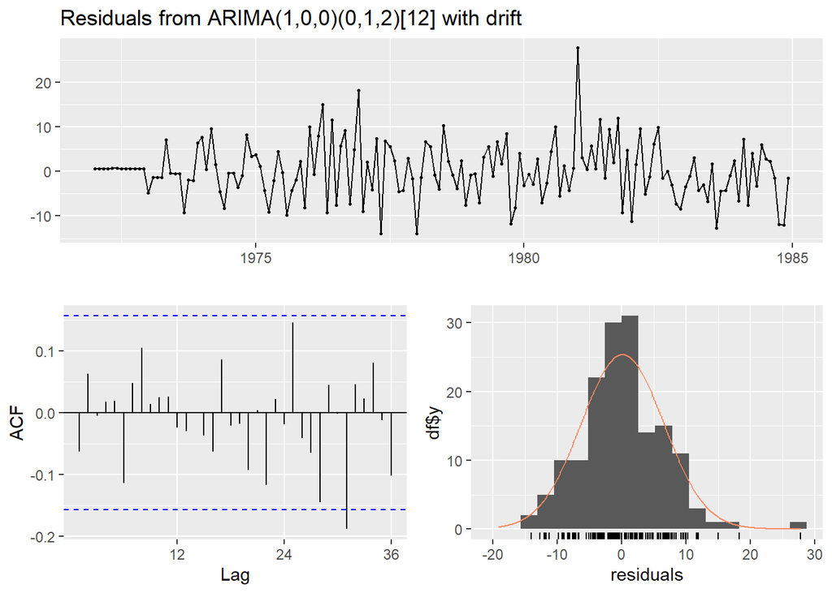

```
##
##  Ljung-Box test
##
## data:  Residuals from ARIMA(1,0,0)(0,1,2)[12] with drift
## Q* = 12.868, df = 21, p-value = 0.9132
##
## Model df: 3.   Total lags used: 24
```

```r
checkresiduals(sales_forecast)
```

This is a convenient function in the forecast package that performs a Ljung-Box test on the residuals of the forecast. The result shows:

- Q = 12.868*, p-value = 0.9132: The p-value is again greater than 0.05, which means the residuals are not autocorrelated, confirming that the model is well-specified.

The plot shows white noise, ACF and distribution of residuals. White noise simply is the error terms that still remains after modeling. White noise has the following characteristics

- Zero Mean: The average of the residuals (errors) should be close to zero.
- Constant Variance: The variance of the residuals should be constant over time, which means no heteroscedasticity (no changing variance as time progresses).
- No Autocorrelation: There should be no significant autocorrelation at any lags (i.e., the errors from one time point should not be related to errors from another time point).
- Normally Distributed: Often, it is assumed that the residuals are normally distributed, although this is not strictly required for a model to be good.

### 13. Analyzing Residuals with ACF and PACF

We can also examine the ACF and PACF plots of the residuals to check for any remaining autocorrelation. After fitting a time series model, if there’s still significant autocorrelation in the residuals, it suggests that the model has not fully captured the temporal dependencies. Residuals should resemble white noise, meaning they should be normally distributed with a mean of zero and no autocorrelation.

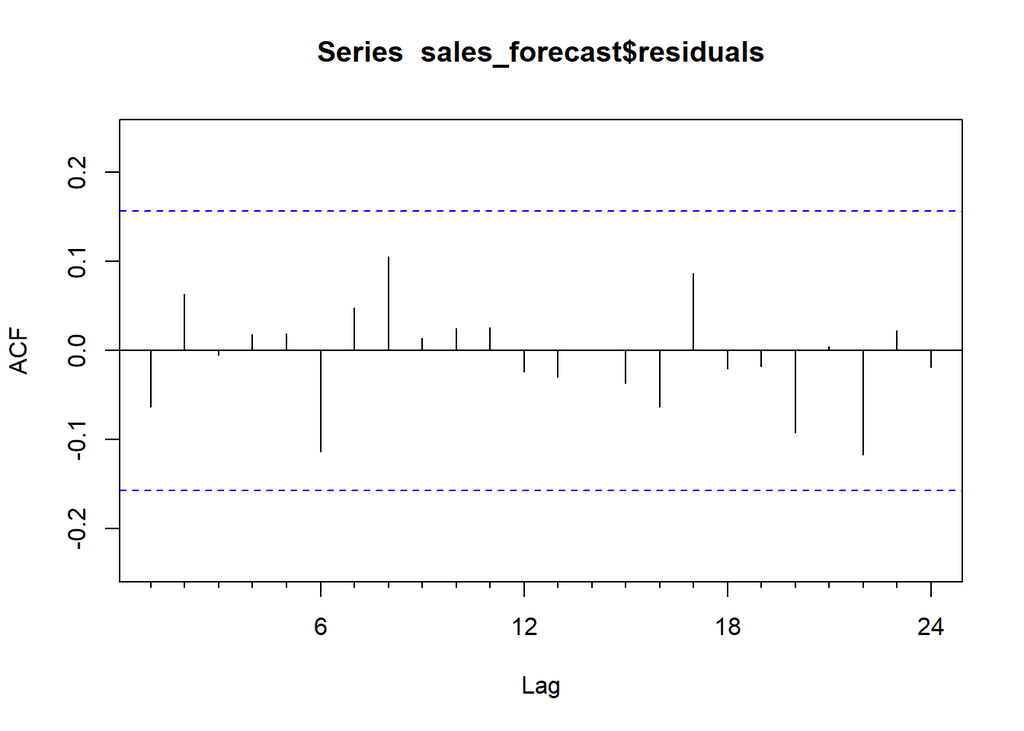

```r
Acf(sales_forecast$residuals)
```

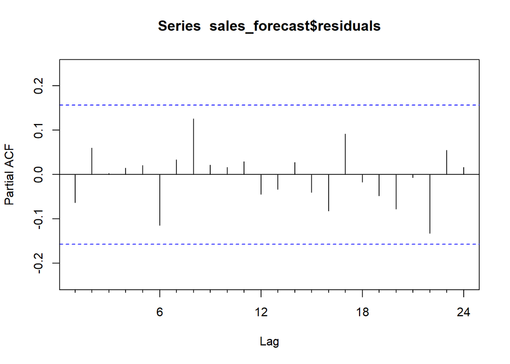

```r
Pacf(sales_forecast$residuals)
```

- ACF: The autocorrelation function shows the correlation of residuals at different lags. Ideally, we want all autocorrelations to be near zero, indicating no remaining patterns.
- PACF: The partial autocorrelation function helps us determine if there are still any significant lags that the model has missed.

Here, as none of the vertical lines are crossing the horizontal dots, it can be concluded that there is no autcorrelation among the residuals.

### 14. Forecast Accuracy Metrics

Finally, we can compute the accuracy of the model using several performance metrics:

```r
accuracy(sales_model)
```

```
##                     ME     RMSE      MAE       MPE      MAPE      MASE
## Training set 0.1285307 6.390803 4.798829 0.0116146 0.6393458 0.2243609
##                    ACF1
## Training set -0.0632192
```

- ME (Mean Error): The average of the residuals (errors) over the training set. A small value close to zero indicates that the model is unbiased.
- RSE (Root Mean Squared Error): Measures the average magnitude of the residuals. Lower RMSE indicates better model fit.
- MAE (Mean Absolute Error): The average absolute difference between the predicted and actual values.
- MPE (Mean Percentage Error): The average of the percentage errors.
- MAPE (Mean Absolute Percentage Error): The average absolute percentage error. This metric gives a sense of how large the errors are relative to the actual values.
- MASE (Mean Absolute Scaled Error): A scaled version of MAE, used to compare models across different time series with different scales.
- ACF1: The autocorrelation of the residuals at lag 1. Ideally, this value should be close to zero.

**Results**

- ME = 0.1285: The model is almost unbiased (very small mean error).
- RMSE = 6.3908: The average prediction error is approximately 6.39 units.
- MAE = 4.7988: The average absolute error is about 4.80 units.
- MAPE = 0.6393: The average percentage error is approximately 0.64%, which is quite low, indicating good prediction accuracy.
- ACF1 = -0.0632: The autocorrelation at lag 1 is very close to zero, indicating that there’s no remaining autocorrelation in the residuals.

### Plotting the predicted line and original line.

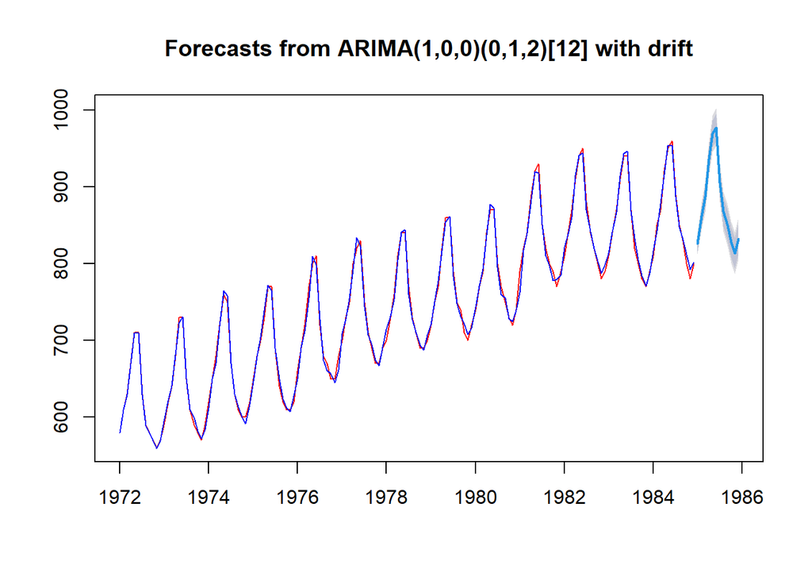

```r
plot(sales_forecast, col = "red")
lines(fitted(sales_forecast), col = "blue")
```

This function gives us the plot to visually assist us in comparing the original and modeled values.

**Note: the accuracy assessment and all the stuffs are done in the model result in the other tutorial. It doesn’t matter if we do the assessment in the model residuals or the forecast residuals. The residuals are the same in both.***